# IODS course project

### Multiple correspondence analysis

Multiple correspondence analysis (MCA) is a technique to analyse nominal categorical data. It is used to detect and portray underlying structures in a dataset and it resembles PCA. The results of MCA are often represented as a two-dimensional “map”.

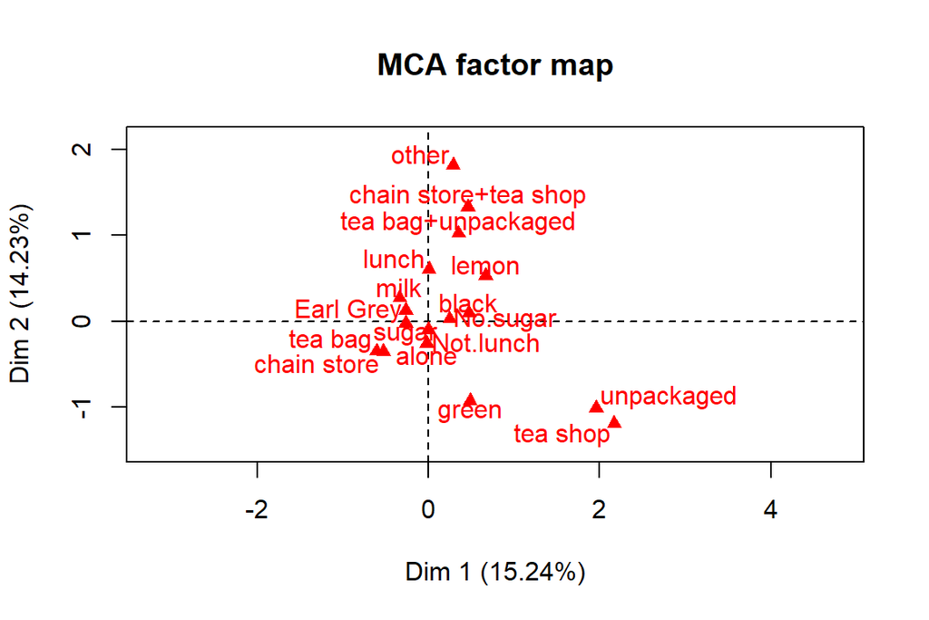

```r
# multiple correspondence analysis
mca <- MCA(tea_time, graph = FALSE)

# summary of the model
#mca
#mca$eig

# visualize MCA
plot(mca, invisible=c("ind"), graph.type = "classic")
```

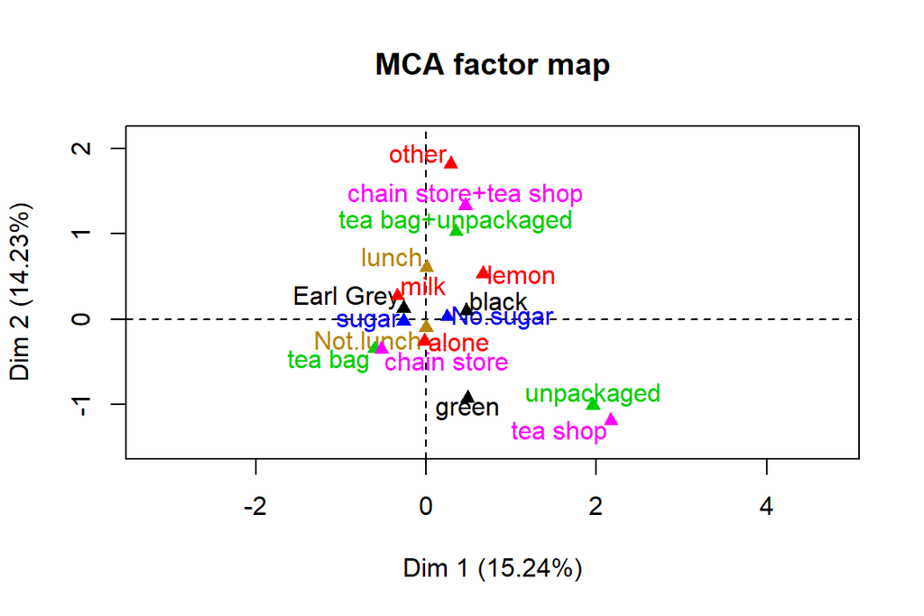

```r
plot(mca, invisible=c("ind"), graph.type = "classic", habillage = "quali")
```

The first plot has variables and their levels drawn as clusters within two dimensions. The second plot is otherwise the same, but the levels of the variables share a colour. For example, different tea types are drawn with black ink and the place of purchase uses pink ink.

It seems that unpackaged tea is most often bought from tea shops (no big surprises here). Another cluster is at the top of the plot. It seems to concern flexible or undecided people, depending on your point of view. The favourite place to buy tea is both chain store and tea shop. Similarly, these people drink both unpackaged tea and tea from tea bags. The third cluster is in the bottom left. here the favoured way to buy tea is tea bags from chain stores. Additionally, this tea is drunk without adding anything. Lastly, it seems that black tea is most often drunk without sugar.

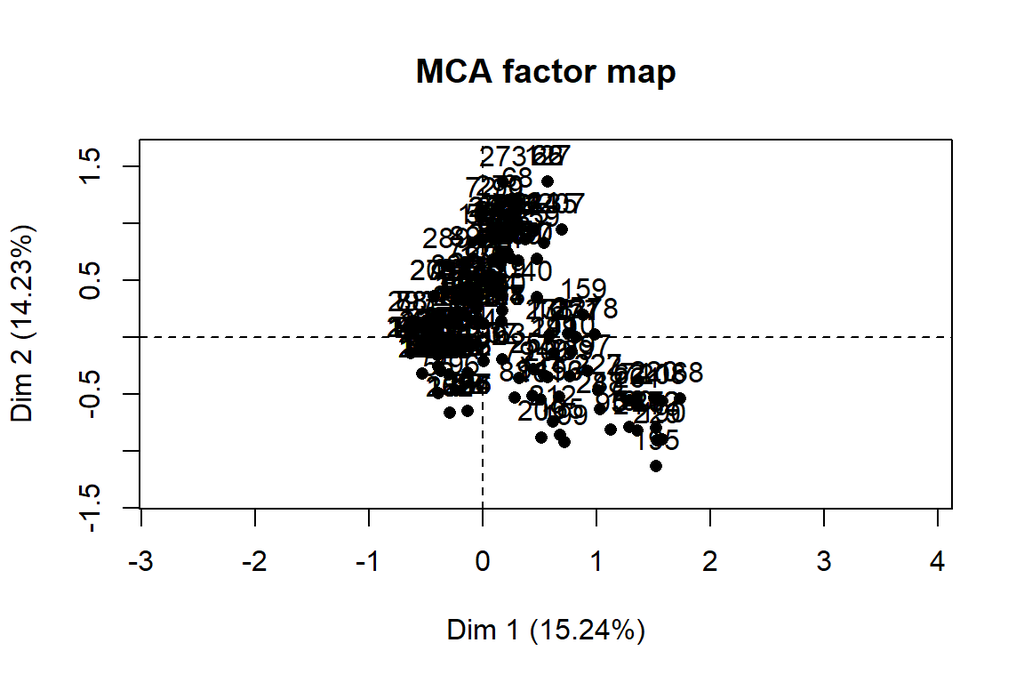

```r
plot(mca, invisible=c("var"), graph.type = "classic")
```

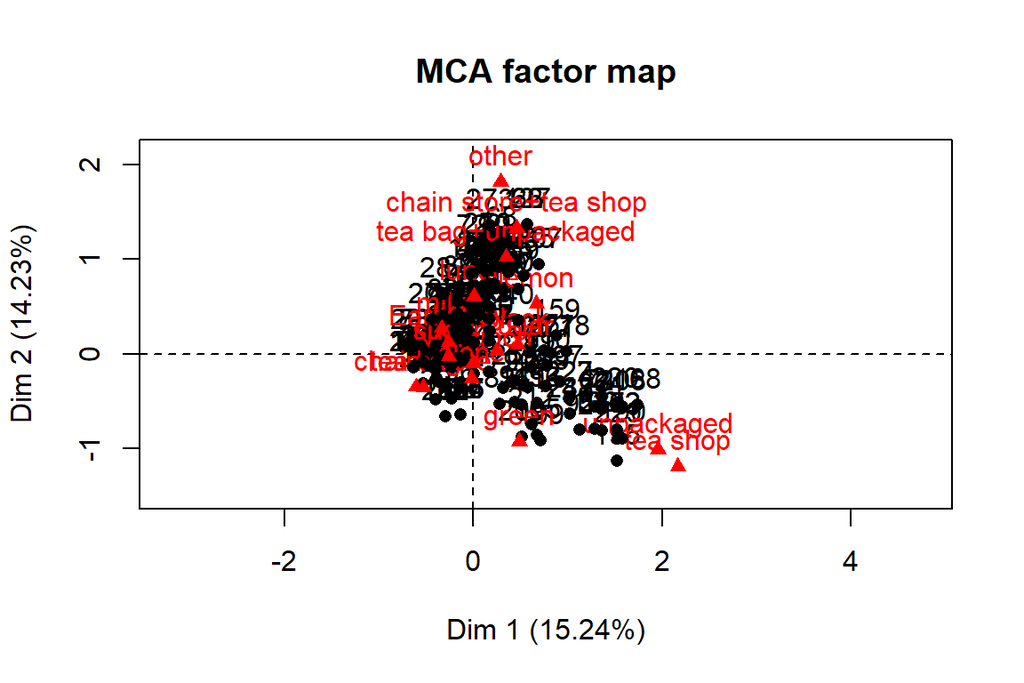

```r
plot(mca, invisible=c("none"), graph.type = "classic")
```

The next plot has the observations or individuals in it. The plot after that has both individuals and variables.

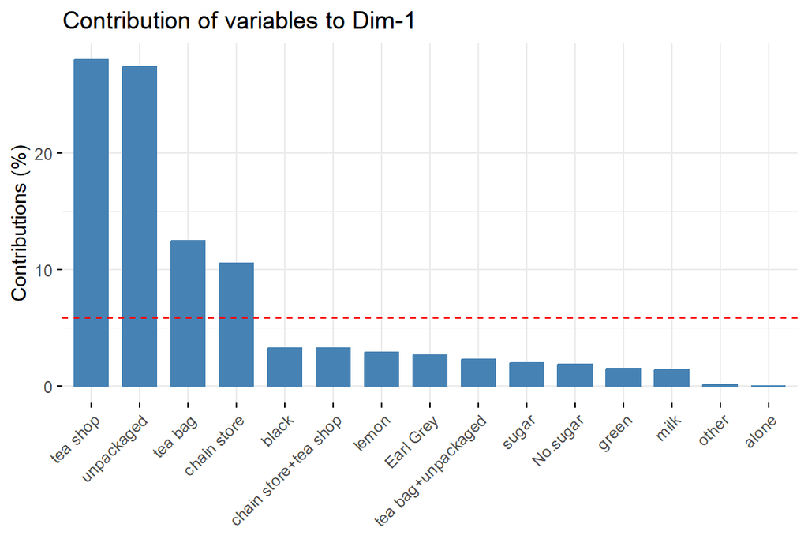

```r
fviz_contrib(mca, choice = "var", axes = 1, top = 15)
```

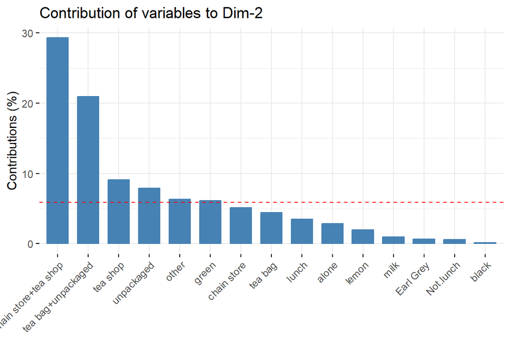

```r
# Contributions of rows to dimension 2
fviz_contrib(mca, choice = "var", axes = 2, top = 15)
```

These two plots kinda confirm my previous interpretation. The plots show us how different variables contribute to dimensions one and two. The first one has a tea shop and unpackaged tea as its main components. Dimension two on the other hand has a chain store + tea shop and tea bag + unpackaged tea as its main contributors.

In conclusion, it seems that the place of purchase and the type of the purchases (tea bags, unpackaged or both) form the clearest cluster in this data. Unsurprisingly, unpackaged tea is often bought from tea shops and tea bags are bought from chain stores.

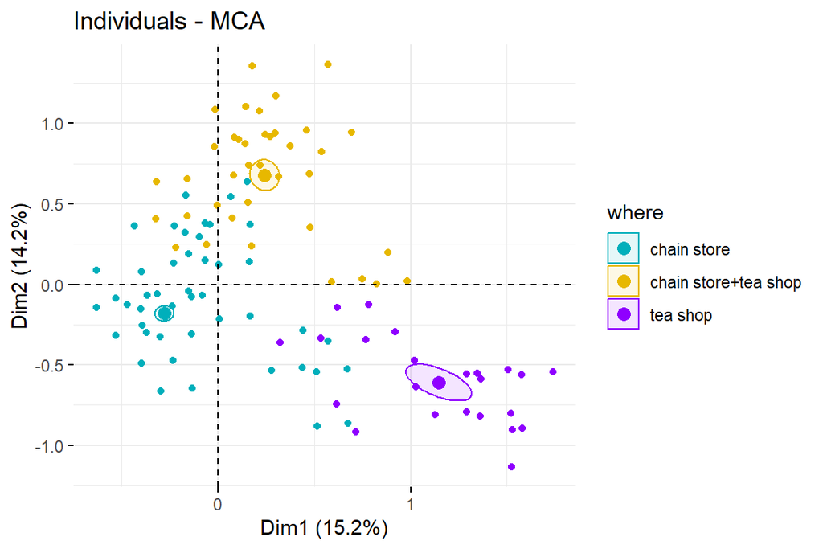

```r
fviz_mca_ind(mca,
             label = "none", # hide individual labels
             habillage = "where", # color by groups
             palette = c("#00AFBB", "#E7B800", "#8f00ff"),
             addEllipses = TRUE, ellipse.type = "confidence",
             ggtheme = theme_minimal())
```

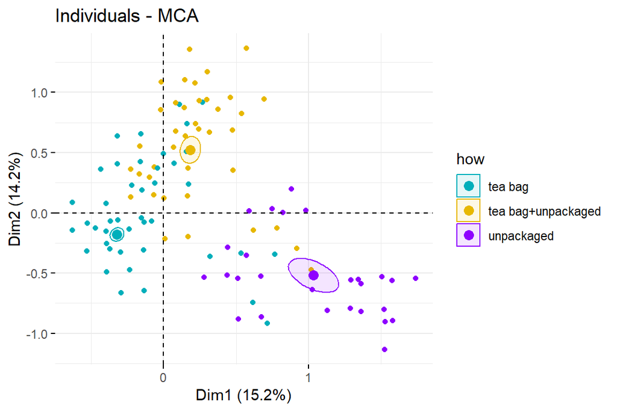

```r
fviz_mca_ind(mca,
             label = "none", # hide individual labels
             habillage = "how", # color by groups
             palette = c("#00AFBB", "#E7B800", "#8f00ff"),
             addEllipses = TRUE, ellipse.type = "confidence",
             ggtheme = theme_minimal())
```

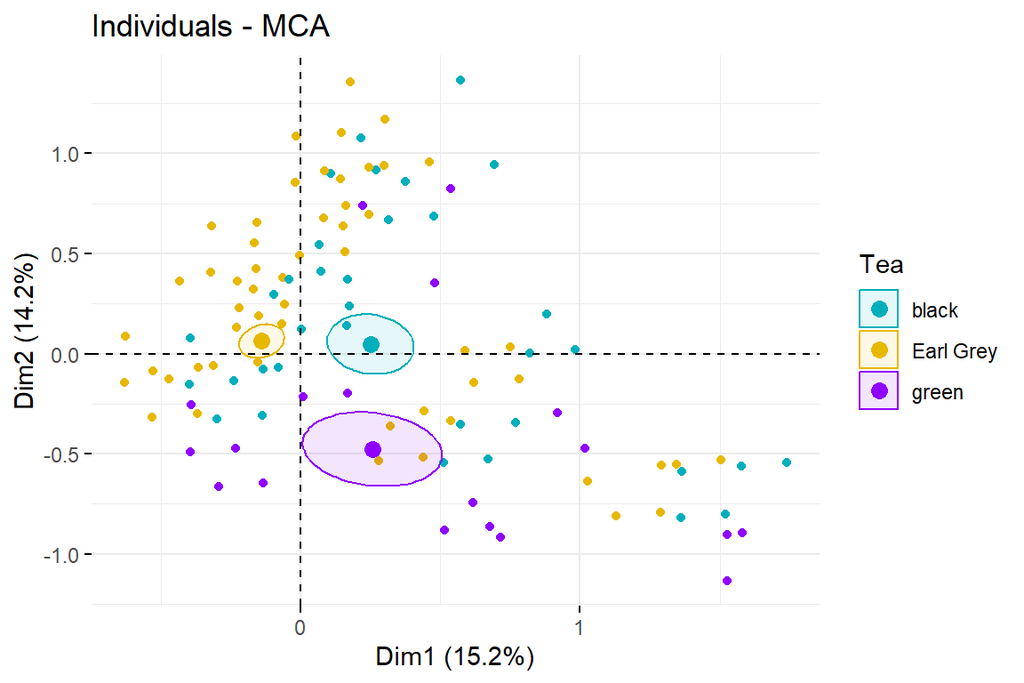

```r
fviz_mca_ind(mca,
             label = "none", # hide individual labels
             habillage = "Tea", # color by groups
             palette = c("#00AFBB", "#E7B800", "#8f00ff"),
             addEllipses = TRUE, ellipse.type = "confidence",
             ggtheme = theme_minimal())
```